# Figure S5

John Favate

2021-01-08 17:03:39

```r
# Prevent printing of warnings and such in the HTML
knitr::opts_chunk$set(warning = FALSE, message = FALSE, fig.align = "center")
```

```r
library(tidyverse)
library(gridExtra)
library(ggridges)
library(ggforce)
library(ggpubr)
library(patchwork)

all.data <- read_csv("../../data_frames/all_data.csv")

kdf <- read_csv("../../data_frames/table_s1_read_counts.csv")
```

Line order and colors for axis.

```r
mut.levels <- all.data %>%
  select(line, mutator) %>%
  arrange(mutator, line) %>%
  unique() %>%
  pull(line)

all.data$line <- factor(all.data$line, levels = mut.levels)

mut.colors <- c(rep("black", 6), rep("firebrick3", 5))
```

### Panel A

Correlations based on TPM

```r
adf <- kdf

mut.colors.a <- c(rep("black", 8), rep("firebrick3", 5))

mut.levels.a <- c("REL606", "REL607", mut.levels)
```

This performs line to line correlations based on log10(tpm). Genes with TPM of 0 would end up as Inf in the transformation, they are replaced with NA. It yields a list of two correlation matrices.

```r
cor.mats <- adf %>%
  filter(grepl("ECB_", target_id)) %>%
  group_by(seqtype, line, target_id) %>%
  summarise(mean_tpm = mean(tpm)) %>%
  ungroup() %>%
  split(.$seqtype) %>%
  map(function(x){
    # make a df suitable for running cor on
    df <- x %>%
      select(-seqtype) %>%
      mutate(mean_tpm = ifelse(mean_tpm != 0, log10(mean_tpm), NA)) %>%
      pivot_wider(names_from = line, values_from = mean_tpm) %>%
      select(-target_id)

    # run line to line cors
    cor.mat <- cor(df, use = "pairwise.complete.obs", method = "spearman")
  })

cor.mats
```

```
## $ribo
##            Ara-1     Ara-2     Ara-3     Ara-4     Ara-5     Ara-6     Ara+1
## Ara-1  1.0000000 0.9497506 0.9420856 0.9656860 0.9531193 0.9656245 0.9453363
## Ara-2  0.9497506 1.0000000 0.9481054 0.9688182 0.9422944 0.9576665 0.9244168
## Ara-3  0.9420856 0.9481054 1.0000000 0.9489588 0.9400990 0.9540838 0.9160458
## Ara-4  0.9656860 0.9688182 0.9489588 1.0000000 0.9582695 0.9687867 0.9422851
## Ara-5  0.9531193 0.9422944 0.9400990 0.9582695 1.0000000 0.9597278 0.9567957
## Ara-6  0.9656245 0.9576665 0.9540838 0.9687867 0.9597278 1.0000000 0.9473793
## Ara+1  0.9453363 0.9244168 0.9160458 0.9422851 0.9567957 0.9473793 1.0000000
## Ara+2  0.9557869 0.9454918 0.9383571 0.9669805 0.9630310 0.9561710 0.9499470
## Ara+3  0.9504896 0.9357572 0.9345121 0.9636127 0.9536197 0.9527598 0.9459530
## Ara+4  0.9585773 0.9492919 0.9386730 0.9645551 0.9629967 0.9731840 0.9523903
## Ara+5  0.9463978 0.9308192 0.9334645 0.9452738 0.9579137 0.9551145 0.9541700
## REL606 0.9578411 0.9540974 0.9444270 0.9637502 0.9538152 0.9736934 0.9393605
## REL607 0.9426689 0.9354200 0.9410520 0.9451475 0.9557970 0.9670060 0.9443309
##            Ara+2     Ara+3     Ara+4     Ara+5    REL606    REL607
## Ara-1  0.9557869 0.9504896 0.9585773 0.9463978 0.9578411 0.9426689
## Ara-2  0.9454918 0.9357572 0.9492919 0.9308192 0.9540974 0.9354200
## Ara-3  0.9383571 0.9345121 0.9386730 0.9334645 0.9444270 0.9410520
## Ara-4  0.9669805 0.9636127 0.9645551 0.9452738 0.9637502 0.9451475
## Ara-5  0.9630310 0.9536197 0.9629967 0.9579137 0.9538152 0.9557970
## Ara-6  0.9561710 0.9527598 0.9731840 0.9551145 0.9736934 0.9670060
## Ara+1  0.9499470 0.9459530 0.9523903 0.9541700 0.9393605 0.9443309
## Ara+2  1.0000000 0.9733801 0.9562544 0.9674629 0.9483401 0.9478391
## Ara+3  0.9733801 1.0000000 0.9508612 0.9485916 0.9491800 0.9479472
## Ara+4  0.9562544 0.9508612 1.0000000 0.9613524 0.9633164 0.9635260
## Ara+5  0.9674629 0.9485916 0.9613524 1.0000000 0.9407412 0.9547000
## REL606 0.9483401 0.9491800 0.9633164 0.9407412 1.0000000 0.9777206
## REL607 0.9478391 0.9479472 0.9635260 0.9547000 0.9777206 1.0000000
##
## $rna
##            Ara-1     Ara-2     Ara-3     Ara-4     Ara-5     Ara-6     Ara+1
## Ara-1  1.0000000 0.9532623 0.9419039 0.9640904 0.9513557 0.9595953 0.9487018
## Ara-2  0.9532623 1.0000000 0.9446906 0.9694615 0.9362279 0.9514781 0.9195694
## Ara-3  0.9419039 0.9446906 1.0000000 0.9460331 0.9336801 0.9439285 0.9139687
## Ara-4  0.9640904 0.9694615 0.9460331 1.0000000 0.9510319 0.9638509 0.9429765
## Ara-5  0.9513557 0.9362279 0.9336801 0.9510319 1.0000000 0.9515783 0.9591299
## Ara-6  0.9595953 0.9514781 0.9439285 0.9638509 0.9515783 1.0000000 0.9459266
## Ara+1  0.9487018 0.9195694 0.9139687 0.9429765 0.9591299 0.9459266 1.0000000
## Ara+2  0.9615163 0.9446922 0.9421404 0.9687312 0.9626060 0.9532625 0.9493302
## Ara+3  0.9516390 0.9361377 0.9344238 0.9617555 0.9504381 0.9511639 0.9447641
## Ara+4  0.9586032 0.9487705 0.9384576 0.9623230 0.9592537 0.9715375 0.9492371
## Ara+5  0.9414476 0.9209248 0.9281308 0.9352749 0.9484428 0.9422361 0.9400184
## REL606 0.9484904 0.9436965 0.9385410 0.9525915 0.9426056 0.9700669 0.9294599
## REL607 0.9383402 0.9299657 0.9383141 0.9405760 0.9528083 0.9670682 0.9376034
##            Ara+2     Ara+3     Ara+4     Ara+5    REL606    REL607
## Ara-1  0.9615163 0.9516390 0.9586032 0.9414476 0.9484904 0.9383402
## Ara-2  0.9446922 0.9361377 0.9487705 0.9209248 0.9436965 0.9299657
## Ara-3  0.9421404 0.9344238 0.9384576 0.9281308 0.9385410 0.9383141
## Ara-4  0.9687312 0.9617555 0.9623230 0.9352749 0.9525915 0.9405760
## Ara-5  0.9626060 0.9504381 0.9592537 0.9484428 0.9426056 0.9528083
## Ara-6  0.9532625 0.9511639 0.9715375 0.9422361 0.9700669 0.9670682
## Ara+1  0.9493302 0.9447641 0.9492371 0.9400184 0.9294599 0.9376034
## Ara+2  1.0000000 0.9722396 0.9575027 0.9612299 0.9426156 0.9456276
## Ara+3  0.9722396 1.0000000 0.9513518 0.9362120 0.9427861 0.9442784
## Ara+4  0.9575027 0.9513518 1.0000000 0.9552028 0.9587084 0.9652475
## Ara+5  0.9612299 0.9362120 0.9552028 1.0000000 0.9272444 0.9427714
## REL606 0.9426156 0.9427861 0.9587084 0.9272444 1.0000000 0.9806923
## REL607 0.9456276 0.9442784 0.9652475 0.9427714 0.9806923 1.0000000
```

Half of each matrix is redundant, as is the diagonal. Make one matrix where the upper triangle is rna and the lower is ribo

```r
cor.combo <- cor.mats$ribo

cor.combo[upper.tri(cor.combo)] <- cor.mats$rna[upper.tri(cor.mats$rna)]

cor.combo
```

```
##            Ara-1     Ara-2     Ara-3     Ara-4     Ara-5     Ara-6     Ara+1
## Ara-1  1.0000000 0.9532623 0.9419039 0.9640904 0.9513557 0.9595953 0.9487018
## Ara-2  0.9497506 1.0000000 0.9446906 0.9694615 0.9362279 0.9514781 0.9195694
## Ara-3  0.9420856 0.9481054 1.0000000 0.9460331 0.9336801 0.9439285 0.9139687
## Ara-4  0.9656860 0.9688182 0.9489588 1.0000000 0.9510319 0.9638509 0.9429765
## Ara-5  0.9531193 0.9422944 0.9400990 0.9582695 1.0000000 0.9515783 0.9591299
## Ara-6  0.9656245 0.9576665 0.9540838 0.9687867 0.9597278 1.0000000 0.9459266
## Ara+1  0.9453363 0.9244168 0.9160458 0.9422851 0.9567957 0.9473793 1.0000000
## Ara+2  0.9557869 0.9454918 0.9383571 0.9669805 0.9630310 0.9561710 0.9499470
## Ara+3  0.9504896 0.9357572 0.9345121 0.9636127 0.9536197 0.9527598 0.9459530
## Ara+4  0.9585773 0.9492919 0.9386730 0.9645551 0.9629967 0.9731840 0.9523903
## Ara+5  0.9463978 0.9308192 0.9334645 0.9452738 0.9579137 0.9551145 0.9541700
## REL606 0.9578411 0.9540974 0.9444270 0.9637502 0.9538152 0.9736934 0.9393605
## REL607 0.9426689 0.9354200 0.9410520 0.9451475 0.9557970 0.9670060 0.9443309
##            Ara+2     Ara+3     Ara+4     Ara+5    REL606    REL607
## Ara-1  0.9615163 0.9516390 0.9586032 0.9414476 0.9484904 0.9383402
## Ara-2  0.9446922 0.9361377 0.9487705 0.9209248 0.9436965 0.9299657
## Ara-3  0.9421404 0.9344238 0.9384576 0.9281308 0.9385410 0.9383141
## Ara-4  0.9687312 0.9617555 0.9623230 0.9352749 0.9525915 0.9405760
## Ara-5  0.9626060 0.9504381 0.9592537 0.9484428 0.9426056 0.9528083
## Ara-6  0.9532625 0.9511639 0.9715375 0.9422361 0.9700669 0.9670682
## Ara+1  0.9493302 0.9447641 0.9492371 0.9400184 0.9294599 0.9376034
## Ara+2  1.0000000 0.9722396 0.9575027 0.9612299 0.9426156 0.9456276
## Ara+3  0.9733801 1.0000000 0.9513518 0.9362120 0.9427861 0.9442784
## Ara+4  0.9562544 0.9508612 1.0000000 0.9552028 0.9587084 0.9652475
## Ara+5  0.9674629 0.9485916 0.9613524 1.0000000 0.9272444 0.9427714
## REL606 0.9483401 0.9491800 0.9633164 0.9407412 1.0000000 0.9806923
## REL607 0.9478391 0.9479472 0.9635260 0.9547000 0.9777206 1.0000000
```

```r
cor.df <- cor.combo %>%
  as.data.frame() %>%
  rownames_to_column("line") %>%
  pivot_longer(cols = !line, names_to = "other_line", values_to = "rs") %>%
  filter(line != other_line)

cor.df$line <- factor(cor.df$line, levels = mut.levels.a)

cor.df$other_line <- factor(cor.df$other_line, levels = mut.levels.a)
```

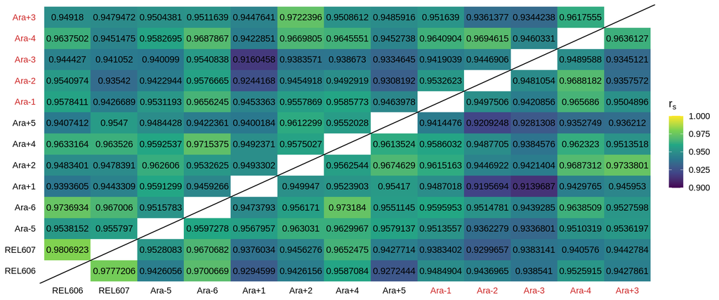

```r
cor.df %>%
  ggplot(aes(line, other_line, fill = rs))+
  geom_raster()+
  scale_fill_viridis_c(option = "D",
                       na.value = "white",
                       name = expression(r[s]),
                       limits = c(.9, 1))+
  theme(panel.background = element_blank(),
        axis.ticks = element_blank(),
        text = element_text(size = 13),
        axis.text = element_text(color = mut.colors.a))+
  labs(x = NULL,
       y = NULL)+
  geom_abline(aes(slope = 1, intercept = 0))+
  geom_text(aes(label = round(rs, 7)))
```

No reason to show the whole number though

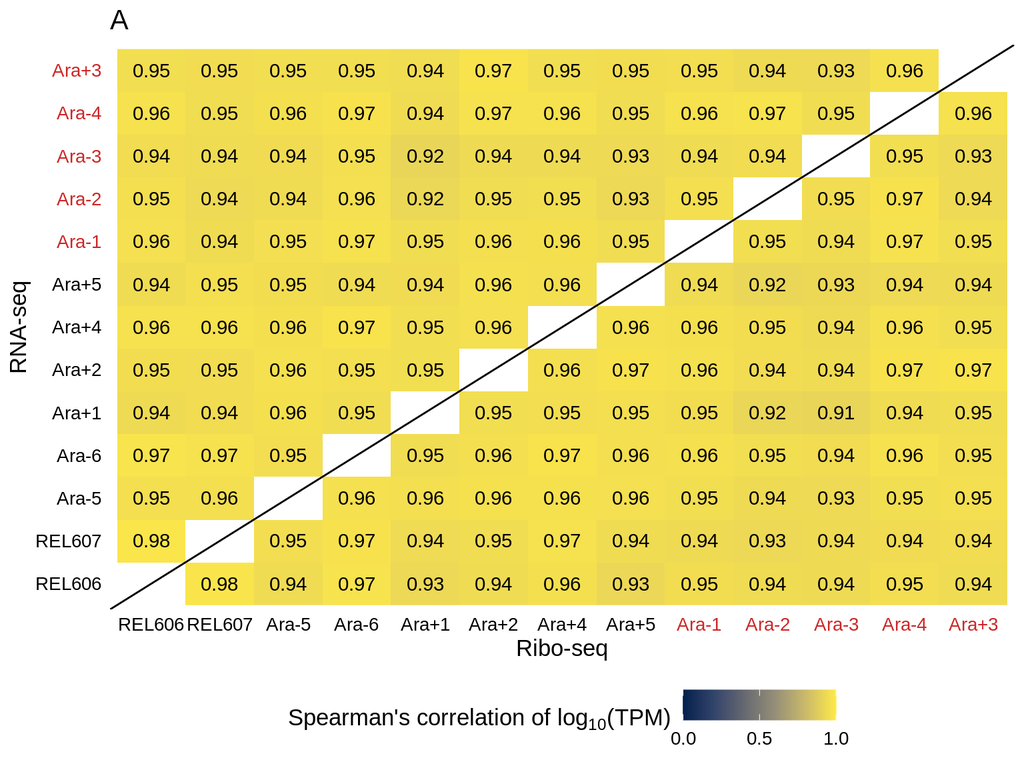

```r
pa <- cor.df %>%
  ggplot(aes(line, other_line, fill = rs, label = signif(rs, 2)))+
  geom_raster()+
  geom_text()+
  scale_fill_viridis_c(option = "E",
                       na.value = "white",
                       name = expression(paste("Spearman's correlation of ", log[10], "(TPM)")),
                       limits = c(0,1),
                       breaks= c(0, .5, 1))+
  theme(panel.background = element_blank(),
        axis.ticks = element_blank(),
        text = element_text(size = 13),
        axis.text = element_text(color = mut.colors.a),
        legend.position = "bottom")+
  labs(x = NULL,
       y = NULL)+
  geom_abline(aes(slope = 1, intercept = 0))+
  labs(title = "A",
       x = "Ribo-seq",
       y = "RNA-seq")

pa
```

### Panel B

A second plot to show the difference between cors to the ancestor vs cors among evolved lines

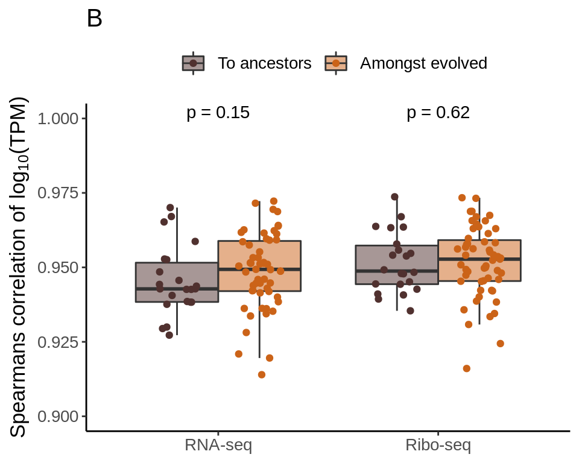

```r
bdf <- kdf %>%
  filter(grepl("ECB_", target_id)) %>%
  group_by(seqtype, line, target_id) %>%
  summarise(mean_tpm = mean(tpm)) %>%
  ungroup() %>%
  split(.$seqtype) %>%
  map(function(x){
    # make a df suitable for running cor on
    df <- x %>%
      select(-seqtype) %>%
      mutate(mean_tpm = ifelse(mean_tpm != 0, log10(mean_tpm), NA)) %>%
      pivot_wider(names_from = line, values_from = mean_tpm) %>%
      select(-target_id)

    # run line to line cors
    cor.mat <- cor(df, use = "pairwise.complete.obs", method = "spearman")

    cor.mat[upper.tri(cor.mat)] <- NA

    cor.mat %>%
      as_tibble(rownames = "line") %>%
      pivot_longer(cols = starts_with("Ara"), names_to = "other_line", values_to = "rs") %>%
      filter(!is.na(rs) & line != other_line)
  }) %>%
  bind_rows(.id = "seqtype") %>%
  mutate(type = ifelse(line %in% c("REL606", "REL607") | other_line %in% c("REL606", "REL607"), "anc", "evo"))

bdf$seqtype <- factor(bdf$seqtype, levels = c("rna", "ribo"))

pb <- bdf %>%
  ggplot(., aes(seqtype, rs, fill = type))+
  geom_boxplot(position = position_dodge(), alpha = .5, outlier.color = NA)+
  geom_jitter(position = position_jitterdodge(jitter.height = 0, jitter.width = .2), aes(color = type))+
  scale_y_continuous(limits = c(.9, 1))+
  stat_compare_means(method = "wilcox.test", label = "p.format")+
  theme_classic()+
  theme(text = element_text(size = 13),
        legend.position = "top")+
  scale_fill_manual(values = c("#50312F", "#cb6318"), name = NULL, labels = c("To ancestors", "Amongst evolved"))+
  scale_color_manual(values = c("#50312F", "#cb6318"), name = NULL, labels = c("To ancestors", "Amongst evolved"))+
  labs(x = NULL,
       y = expression(paste("Spearmans correlation of ", log[10], "(TPM)")),
       title = "B")+
  scale_x_discrete(labels = c("RNA-seq", "Ribo-seq"))

pb
```

### Panel C

Distribution of all fold changes instead of heatmap of all fold changes

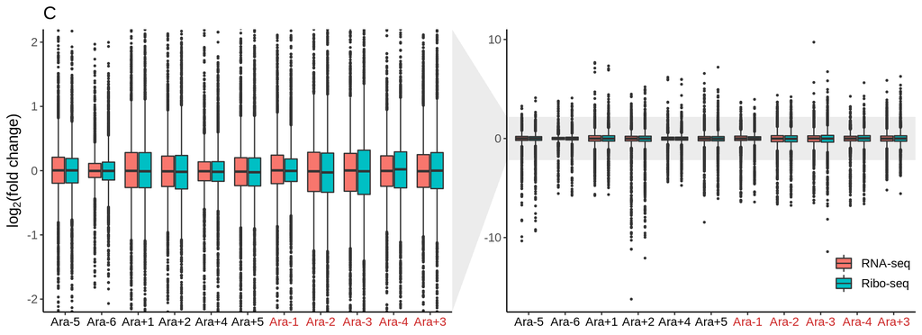

```r
cdf <- all.data %>%
  filter(gene_type == "ECB") %>%
  select(line, target_id, ds_log2foldchange_rna, ds_log2foldchange_ribo) %>%
  pivot_longer(cols = starts_with("ds_"), names_to = "seqtype", values_to = "l2fc")

cdf$line <- factor(cdf$line, levels = mut.levels)

cdf$seqtype <- factor(cdf$seqtype, levels = c("ds_log2foldchange_rna", "ds_log2foldchange_ribo"))

pc <- cdf %>%
  ggplot(., aes(line, l2fc, fill = seqtype))+
  geom_boxplot(outlier.size = .5)+
  theme(panel.background = element_blank(),
        axis.line = element_line(color = "black"),
        text = element_text(size = 13),
        axis.text.x = element_text(color = mut.colors),
        legend.position = c(.95, .15),
        legend.background = element_blank(),
        legend.key = element_blank())+
  labs(x = NULL,
       y = expression(paste(log[2], "(fold change)", sep = "")),
       title = "C")+
  scale_fill_discrete(labels = c("RNA-seq", "Ribo-seq"), name = NULL)+
  facet_zoom(ylim = c(-2,2), zoom.size = 1)

pc
```

### Final figure

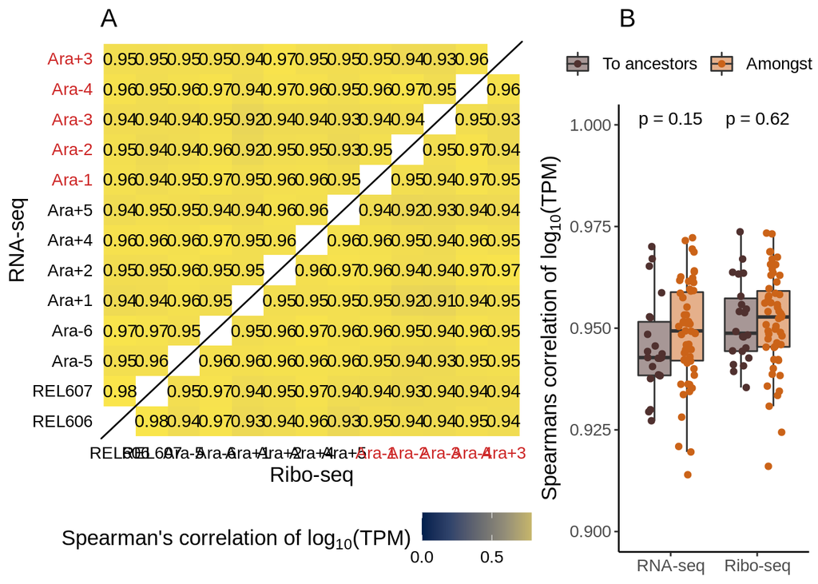

```r
top <- grid.arrange(pa, pb, ncol = 2, widths = c(.65, .35))
```

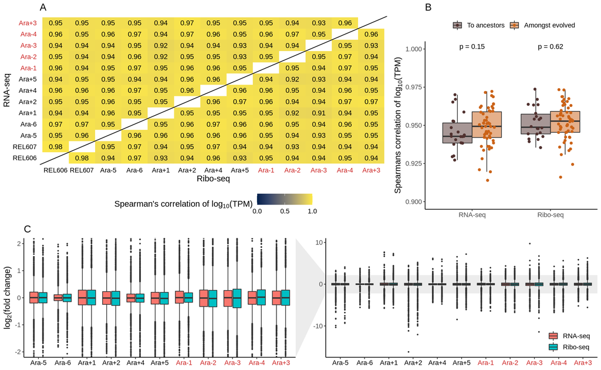

```r
(ff <- grid.arrange(top, pc, ncol = 1, heights = c(.6, .4)))
```

```r
ggsave(ff, filename = "../../figures/c_fig_s5.pdf", width = 13, height = 8)

ggsave(ff, filename = "../../figures/c_fig_s5.png", dpi = 300, width = 13, height = 8)
```